# Working Memory Impairs Joint Simon Effect

Load JSE

Do-Joon Yi

2018-11-02

## 패키지

`tidyr`, `dplyr`, `purrr`를 개별적으로 로드하면 함수들이 충돌하는 경우가 있다. `tidyverse`로 한번에 로드하는 것이 좋다. `lmerTest`는 `lme4`에서 *p* 값을 얻기 위해 필요한데, 없어도 문제는 없다.

```r
pacman::p_load(tidyverse, afex, lme4, lmerTest, ggplot2, papaja, psych, emmeans)
```

## 작업기억 과제

작업기억 과제의 자료 파일을 업로드하고, Group 변인을 Low -> High 순으로 정리하였다.

```r
WW = read.csv('~/Documents/GitHub/JSE/logJSEn64_WMtask.csv', header = TRUE)
str(WW)
```

```
## 'data.frame':    768 obs. of  7 variables:
##  $ SID     : int  101 101 101 101 101 101 101 101 101 101 ...
##  $ Group   : Factor w/ 2 levels "High","Low": 2 2 2 2 2 2 2 2 2 2 ...
##  $ Trial   : int  1 2 3 4 5 6 7 8 9 10 ...
##  $ Probe   : int  1 1 1 2 2 2 2 2 1 2 ...
##  $ Response: int  1 1 1 2 2 2 1 2 1 2 ...
##  $ Correct : int  1 1 1 1 1 1 0 1 1 1 ...
##  $ RT      : num  0.901 0.619 0.688 1.013 0.827 ...
```

```r
WW$Group = factor(WW$Group, levels=c("Low","High"))
headTail(WW)
```

```
##     SID Group Trial Probe Response Correct   RT
## 1   101   Low     1     1        1       1  0.9
## 2   101   Low     2     1        1       1 0.62
## 3   101   Low     3     1        1       1 0.69
## 4   101   Low     4     2        2       1 1.01
## ... ...  <NA>   ...   ...      ...     ...  ...
## 765 232  High     9     2        2       1 0.71
## 766 232  High    10     1        1       1 0.76
## 767 232  High    11     1        1       1 0.68
## 768 232  High    12     1        1       1 0.42
```

### 1. 작업기억 정확율

#### 가. 기술통계

먼저 개인별 자료를 정리한 다음, 전체 참가자의 수행을 집단별로 계산하였다. 고부하 집단과 저부하집단의 정확율을 계산하였다.

```r
wAcc1stLev <- WW %>%
  group_by(Group, SID) %>% # 집단 > 개인 순서로 구분한 후,
  summarise(Accuracy = mean(Correct)) %>% # Correct의 평균을 Accuracy에 넣는다.
  ungroup()
wAcc1stLev
```

```
## # A tibble: 64 x 3
##    Group   SID Accuracy
##    <fct> <int>    <dbl>
##  1 Low     101    0.917
##  2 Low     102    1
##  3 Low     103    1
##  4 Low     104    1
##  5 Low     105    1
##  6 Low     106    1
##  7 Low     107    1
##  8 Low     108    0.917
##  9 Low     109    1
## 10 Low     110    0.667
## # ... with 54 more rows
```

```r
wAcc2ndLev <- wAcc1stLev %>%
  group_by(Group) %>% # 집단으로 구분한 후,
  summarise(Acc = mean(Accuracy), # Accuracy 평균을 Acc에 넣고,
            CI = ci(Accuracy)) %>%  # papaja 패키지의 ci로 95% 집단간 신뢰구간 계산
  ungroup()
colnames(wAcc2ndLev)[2] <- "Accuracy"
wAcc2ndLev
```

```
## # A tibble: 2 x 3
##   Group Accuracy     CI
##   <fct>    <dbl>  <dbl>
## 1 Low      0.940 0.0326
## 2 High     0.891 0.0435
```

저부하 집단의 정확율은 0.9401이고, 고부하 집단의 정확율은 0.8906이었다. 집단간 차이를 t-test로 비교하였다.

#### 나. Plotting

아래는 ggplot2.

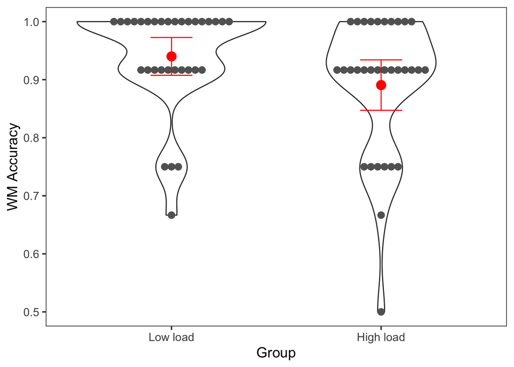

```r
ggplot(wAcc1stLev, aes(x=Group, y=Accuracy)) +
  geom_violin(trim = TRUE) +
  geom_dotplot(binaxis='y', stackdir='center', dotsize=.7, color='#636363', fill='#636363') +
  geom_point(data = wAcc2ndLev, aes(y=Accuracy), color = "red", size=4) +
  geom_errorbar(data = wAcc2ndLev, aes(ymin=Accuracy-CI, ymax=Accuracy+CI),
                color = "red", width=0.2) +
  labs(x="Group", y="WM Accuracy") +
  scale_x_discrete(labels=c("Low load", "High load")) +
  coord_cartesian(ylim=c(.5, 1)) +
  theme_bw(base_size = 14) +
  theme(panel.grid.major = element_blank(),
        panel.grid.minor = element_blank(),
        plot.title = element_text(hjust = .5))
```

아래는 papaja. (2018년 10월 현재, papaja plot은 tibble에서 작동하지 않고, id는 factor이어야만 한다.)

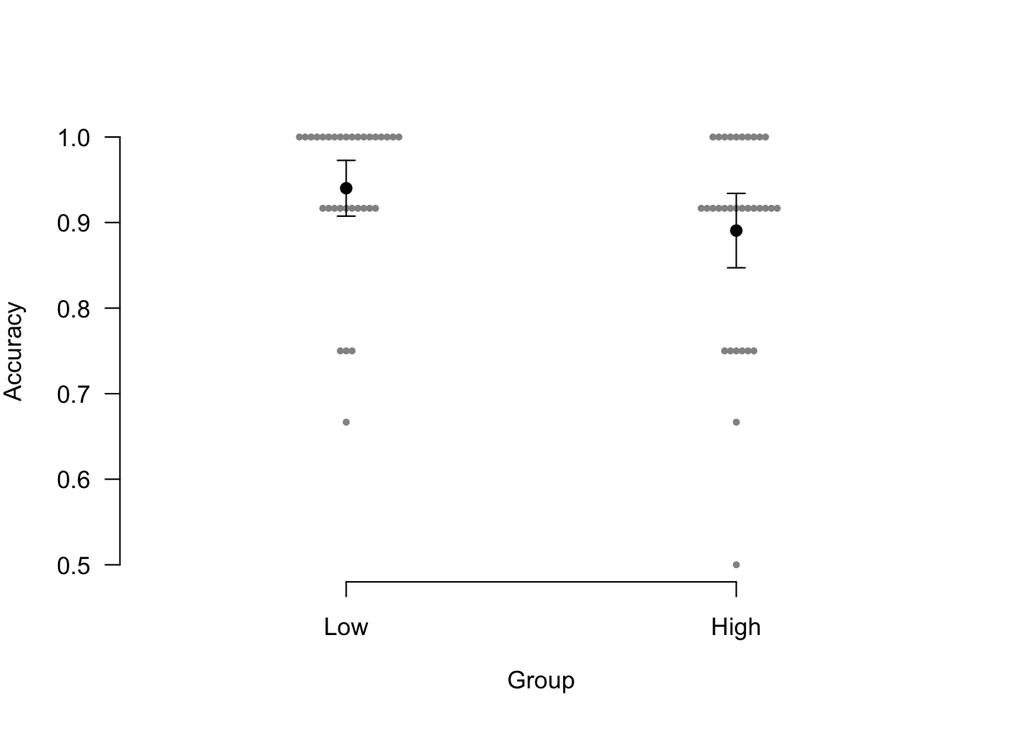

```r
temp <- as.data.frame(wAcc1stLev)
temp$SID <- as.factor(temp$SID)
apa_beeplot(data=temp,
            id="SID", dv="Accuracy", factors="Group",
            ylim = c(.5, 1),
            las=1)
```

#### 다. T-test

```r
g1 <- wAcc1stLev %>% filter(Group=="Low") # low load 집단만 남김
g2 <- wAcc1stLev %>% filter(Group=="High") # high load 집단만 남김
t.test(g1$Accuracy, g2$Accuracy)
```

```
##
##  Welch Two Sample t-test
##
## data:  g1$Accuracy and g2$Accuracy
## t = 1.8576, df = 57.484, p-value = 0.06835
## alternative hypothesis: true difference in means is not equal to 0
## 95 percent confidence interval:
##  -0.003847844  0.102806177
## sample estimates:
## mean of x mean of y
## 0.9401042 0.8906250
```

t-검증에서 집단차는 유의미한 경향성만을 보였다. 그러나 Student’s t-test는 normality 가정을 만족해야 하는데, 작업기억 과제가 쉬웠기 때문에 참가자들의 점수 분포는 정규성과 거리가 멀다. 정규성을 검토한 Shapiro-Wilk 검사 결과는 다음과 같다.[^1]

```r
shapiro.test(g1$Accuracy)
```

```
##
##  Shapiro-Wilk normality test
##
## data:  g1$Accuracy
## W = 0.67944, p-value = 4.344e-07
```

```r
shapiro.test(g2$Accuracy)
```

```
##
##  Shapiro-Wilk normality test
##
## data:  g2$Accuracy
## W = 0.78274, p-value = 1.964e-05
```

#### 라. 비모수통계: Mann-Whitney, Kruskal-Wallis

두 집단 자료 모두 정규성 가정을 만족하지 못하였으므로, Mann-Whitney u test를 실시하였다.[^2]

```r
wilcox.test(Accuracy ~ Group, wAcc1stLev)
```

```
##
##  Wilcoxon rank sum test with continuity correction
##
## data:  Accuracy by Group
## W = 652.5, p-value = 0.04277
## alternative hypothesis: true location shift is not equal to 0
```

Kruskal-Wallis rank sum test 결과는 다음과 같다.

```r
kruskal.test(Accuracy ~ Group, wAcc1stLev)
```

```
##
##  Kruskal-Wallis rank sum test
##
## data:  Accuracy by Group
## Kruskal-Wallis chi-squared = 4.1339, df = 1, p-value = 0.04203
```

#### 마. One-Way ANOVA

참고로 ‘afex’ 패키지의 ‘aov_4’ 함수로 비교하였다. 당연히 결과는 Student’s t-test와 같다. 개인자료를 평균하여 정리한 2nd-level 자료가 아닌 경우에 자동으로 *aggregating* 하여 분석한다.

```r
aov_4(Correct ~ Group + (1|SID), WW)
```

```
## Contrasts set to contr.sum for the following variables: Group
```

```
## Anova Table (Type 3 tests)
##
## Response: Correct
##   Effect    df  MSE      F ges p.value
## 1  Group 1, 62 0.01 3.45 + .05     .07
## ---
## Signif. codes:  0 '***' 0.001 '**' 0.01 '*' 0.05 '+' 0.1 ' ' 1
```

‘aov_car’ 함수를 사용해도 결과는 같다.

```r
aov_car(Correct ~ Group + Error(SID), WW)
```

```
## Contrasts set to contr.sum for the following variables: Group
```

```
## Anova Table (Type 3 tests)
##
## Response: Correct
##   Effect    df  MSE      F ges p.value
## 1  Group 1, 62 0.01 3.45 + .05     .07
## ---
## Signif. codes:  0 '***' 0.001 '**' 0.01 '*' 0.05 '+' 0.1 ' ' 1
```

#### 바. Linear Mixed Modeling

정규성 가정이 필요없고, 무선효과를 설명할 수 있는 LME를 실시하였다.

```r
w2 <- glmer(Correct ~ as.factor(Group) + (1|SID), WW, family = binomial)
summary(w2)
```

```
## Generalized linear mixed model fit by maximum likelihood (Laplace
##   Approximation) [glmerMod]
##  Family: binomial  ( logit )
## Formula: Correct ~ as.factor(Group) + (1 | SID)
##    Data: WW
##
##      AIC      BIC   logLik deviance df.resid
##    434.3    448.3   -214.2    428.3      765
##
## Scaled residuals:
##     Min      1Q  Median      3Q     Max
## -4.1336  0.1815  0.2356  0.3024  0.6961
##
## Random effects:
##  Groups Name        Variance Std.Dev.
##  SID    (Intercept) 0.7983   0.8935
## Number of obs: 768, groups:  SID, 64
##
## Fixed effects:
##                      Estimate Std. Error z value Pr(>|z|)
## (Intercept)            3.1069     0.3188   9.746   <2e-16 ***
## as.factor(Group)High  -0.7196     0.3728  -1.930   0.0536 .
## ---
## Signif. codes:  0 '***' 0.001 '**' 0.01 '*' 0.05 '.' 0.1 ' ' 1
##
## Correlation of Fixed Effects:
##             (Intr)
## as.fctr(G)H -0.722
```

역시 집단차는 유의미한 경향성을 보였다.[^3]

### 2. 작업기억 반응시간 분석

#### 가. 기술통계

```r
cWW <- WW %>% filter(Correct==1) # 정반응만 선별
# nrow(cWW)

aWW <- cWW %>% filter(RT > .15) # anticipatory response 제거
nrow(cWW) - nrow(aWW) # 제거된 반응 없었다.
```

```
## [1] 0
```

```r
tWW <- aWW %>% # trimmed RT
  group_by(Group, SID) %>%
  nest() %>%
  mutate(lbound = map(data, ~mean(.$RT)-3*sd(.$RT)), # lower/upper bound 계산
         ubound = map(data, ~mean(.$RT)+3*sd(.$RT))) %>%
  unnest(lbound, ubound) %>%
  unnest(data) %>%
  mutate(Outlier = (RT < lbound)|(RT > ubound)) %>%
  select(Group, SID, Trial, RT, Outlier)
sum(tWW$Outlier) # 3SD를 벗어난 반응도 없었다.
```

```
## [1] 0
```

```r
# 1st-level
wRT1stLev <- tWW %>%
  filter(Outlier==FALSE) %>%
  group_by(Group, SID) %>% # 집단 > 개인 순서로 구분한 후,
  summarise(RT = mean(RT)) %>% # RT 평균을 RT 넣는다.
  ungroup()
wRT1stLev
```

```
## # A tibble: 64 x 3
##    Group   SID    RT
##    <fct> <int> <dbl>
##  1 Low     101 0.762
##  2 Low     102 0.865
##  3 Low     103 0.988
##  4 Low     104 1.05
##  5 Low     105 1.02
##  6 Low     106 1.08
##  7 Low     107 1.16
##  8 Low     108 0.965
##  9 Low     109 0.962
## 10 Low     110 0.880
## # ... with 54 more rows
```

```r
# 2nd-level
wRT2ndLev <- wRT1stLev %>%
  group_by(Group) %>%
  summarise(gRT = mean(RT),
            CI = ci(RT)) %>%
  ungroup()
colnames(wRT2ndLev)[2] <- "RT"
wRT2ndLev
```

```
## # A tibble: 2 x 3
##   Group    RT     CI
##   <fct> <dbl>  <dbl>
## 1 Low   0.957 0.0553
## 2 High  1.13  0.0750
```

#### 나. Plotting

아래는 ggplot2.

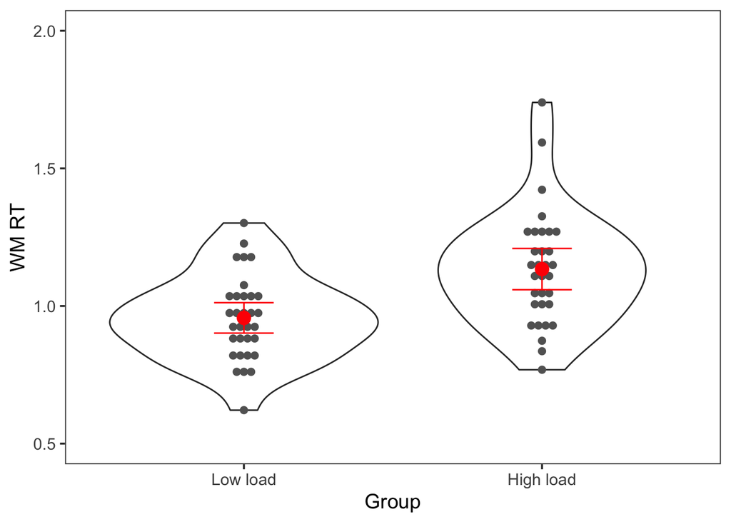

```r
ggplot(wRT1stLev, aes(x=Group, y=RT)) +
  geom_violin(trim = TRUE) +
  geom_dotplot(binaxis='y', stackdir='center', dotsize=.7, color='#636363', fill='#636363') +
  geom_point(data = wRT2ndLev, aes(y=RT), color = "red", size=4) +
  geom_errorbar(data = wRT2ndLev, aes(ymin=RT-CI, ymax=RT+CI),
                color = "red", width=0.2) +
  labs(x="Group", y="WM RT") +
  scale_x_discrete(labels=c("Low load", "High load")) +
  coord_cartesian(ylim=c(.5, 2)) +
  theme_bw(base_size = 14) +
  theme(panel.grid.major = element_blank(),
        panel.grid.minor = element_blank(),
        plot.title = element_text(hjust = .5))
```

아래는 papaja.

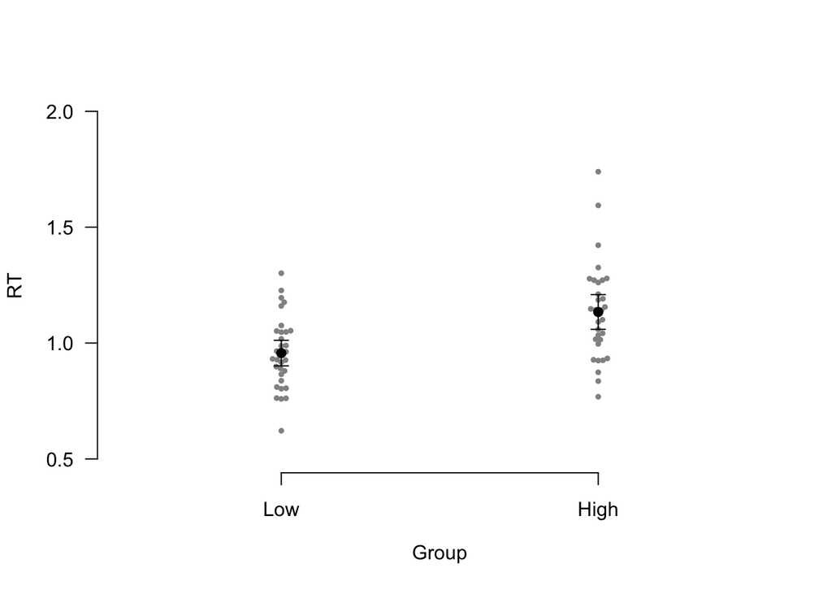

```r
temp <- as.data.frame(wRT1stLev)
temp$SID <- as.factor(temp$SID)
apa_beeplot(data=temp,
            id="SID", dv="RT", factors="Group",
            ylim = c(.5, 2),
            las=1)
```

#### 다. T-test

```r
g1 <- wRT1stLev %>% filter(Group=="Low") # low load 집단만 남김
g2 <- wRT1stLev %>% filter(Group=="High") # high load 집단만 남김
t.test(g1$RT, g2$RT)
```

```
##
##  Welch Two Sample t-test
##
## data:  g1$RT and g2$RT
## t = -3.8816, df = 57.016, p-value = 0.0002719
## alternative hypothesis: true difference in means is not equal to 0
## 95 percent confidence interval:
##  -0.26876807 -0.08583345
## sample estimates:
## mean of x mean of y
## 0.9567039 1.1340047
```

```r
shapiro.test(g1$RT)
```

```
##
##  Shapiro-Wilk normality test
##
## data:  g1$RT
## W = 0.984, p-value = 0.9038
```

```r
shapiro.test(g2$RT)
```

```
##
##  Shapiro-Wilk normality test
##
## data:  g2$RT
## W = 0.95065, p-value = 0.1503
```

## Go/Nogo 과제

Go/Nogo 과제의 자료 파일을 업로드하고, 숫자들을 범주로 바꾸었다.

```r
TT = read.csv('~/Documents/GitHub/JSE/logJSEn64_GNGtask.csv', header = TRUE)
str(TT)
```

```
## 'data.frame':    30720 obs. of  13 variables:
##  $ SID      : int  101 101 101 101 101 101 101 101 101 101 ...
##  $ Group    : Factor w/ 2 levels "High","Low": 2 2 2 2 2 2 2 2 2 2 ...
##  $ Block1   : int  1 1 1 1 1 1 1 1 1 1 ...
##  $ Epoch    : int  1 1 1 1 1 1 1 1 1 1 ...
##  $ Trial    : int  1 2 3 4 5 6 7 8 9 10 ...
##  $ Load     : int  1 1 1 1 1 1 1 1 1 1 ...
##  $ Congruent: int  1 0 0 0 2 1 2 0 0 2 ...
##  $ Target   : int  1 0 0 0 1 1 1 0 0 1 ...
##  $ Color    : int  1 2 2 2 1 1 1 2 2 1 ...
##  $ Direction: int  1 2 1 1 2 1 2 1 1 2 ...
##  $ Response : int  1 0 0 0 1 1 1 0 0 1 ...
##  $ Correct  : int  1 1 1 1 1 1 1 1 1 1 ...
##  $ RT       : num  0.988 0 0 0 0.326 ...
```

```r
TT$Group = factor(TT$Group, levels=c("Low","High"))
TT$Load = factor(TT$Load, levels=1:2, labels=c("Absent","Present"))
TT$Congruent = factor(TT$Congruent, levels=0:2, labels=c("notme","congruent","incongruent"))
TT$Target = factor(TT$Target, levels=0:1, labels=c("not","target"))

headTail(TT) # psych 패키지
```

```
##       SID Group Block1 Epoch Trial    Load Congruent Target Color
## 1     101   Low      1     1     1  Absent congruent target     1
## 2     101   Low      1     1     2  Absent     notme    not     2
## 3     101   Low      1     1     3  Absent     notme    not     2
## 4     101   Low      1     1     4  Absent     notme    not     2
## ...   ...  <NA>    ...   ...   ...    <NA>      <NA>   <NA>   ...
## 30717 232  High      1     4   477 Present     notme    not     1
## 30718 232  High      1     4   478 Present     notme    not     1
## 30719 232  High      1     4   479 Present congruent target     2
## 30720 232  High      1     4   480 Present     notme    not     1
##       Direction Response Correct   RT
## 1             1        1       1 0.99
## 2             2        0       1    0
## 3             1        0       1    0
## 4             1        0       1    0
## ...         ...      ...     ...  ...
## 30717         2        0       1    0
## 30718         1        0       1    0
## 30719         2        1       1  0.3
## 30720         1        0       1    0
```

### 1. Go/Nogo 과제 반응시간

#### 가. 기술통계

각 참가자가 두 명씩 짝을 이루어 실험을 수행했고 절반의 시행에서만 자신의 표적이 출현하였다. 따라서 자신의 표적에 대해서 올바르게 반응한 시행만을 추출하였다. 그 다음, 150ms 보다 빠른 반응을 제거하고 3SD 기준을 적용하여 가외치도 제거하였다.

```r
cTT <- TT %>%
  filter(Congruent!="notme", Correct==1) %>% # 표적시행과 정반응만 선별
  droplevels %>% # "notme" level 제거
  mutate(RT = RT*1000) # ms 단위로 변환
unique(cTT$Congruent)
```

```
## [1] congruent   incongruent
## Levels: congruent incongruent
```

```r
aTT <- cTT %>% filter(RT > 150) # anticipatory response 제거
nrow(cTT) - nrow(aTT) # 4 시행 제거됨
```

```
## [1] 4
```

```r
100*(nrow(cTT) - nrow(aTT))/nrow(aTT) # 0.03% 제거된 셈이다.
```

```
## [1] 0.02678093
```

```r
tTT <- aTT %>% # trimmed RT
  group_by(Group, Load, Congruent, SID) %>%
  nest() %>%
  mutate(lbound = map(data, ~mean(.$RT)-3*sd(.$RT)), # lower/upper bound 계산
         ubound = map(data, ~mean(.$RT)+3*sd(.$RT))) %>%
  unnest(lbound, ubound) %>%
  unnest(data) %>%
  mutate(Outlier = (RT < lbound)|(RT > ubound)) %>%
  select(Group, Load, Congruent, SID, Epoch, Trial, RT, Outlier)
sum(tTT$Outlier) # 3SD를 벗어난 반응도 없었다.
```

```
## [1] 169
```

```r
100*sum(tTT$Outlier)/nrow(aTT) # 1.13% 제거되었다.
```

```
## [1] 1.131494
```

```r
sTT <- tTT %>% filter(!Outlier) # 가외치 제외한 최종 반응시간 자료
```

유효시행들을 집단 > 부하 > 일치 > 개인 순서로 구분하여 1st-level summmary를 만들고, 일치효과를 계산하였다. 마지막으로 전체 참가자의 평균인 2nd-level summary를 만들었다.

```r
# 1st-level
gRT1stLev <- tTT %>%
  filter(Outlier==FALSE) %>%
  group_by(Group, Load, Congruent, SID) %>% # 집단 > 부하 > 일치 > 개인 순서로 구분,
  summarise(RT = mean(RT)) %>%
  ungroup()
gRT1stLev
```

```
## # A tibble: 256 x 5
##    Group Load   Congruent   SID    RT
##    <fct> <fct>  <fct>     <int> <dbl>
##  1 Low   Absent congruent   101  331.
##  2 Low   Absent congruent   102  380.
##  3 Low   Absent congruent   103  322.
##  4 Low   Absent congruent   104  343.
##  5 Low   Absent congruent   105  340.
##  6 Low   Absent congruent   106  358.
##  7 Low   Absent congruent   107  376.
##  8 Low   Absent congruent   108  378.
##  9 Low   Absent congruent   109  381.
## 10 Low   Absent congruent   110  366.
## # ... with 246 more rows
```

```r
gRT1stLev2 <- gRT1stLev %>% # 일치효과 계산
  spread(Congruent, RT) %>%
  mutate(Congruency = incongruent - congruent) %>%
  select(Group, Load, SID, Congruency)
gRT1stLev2
```

```
## # A tibble: 128 x 4
##    Group Load     SID Congruency
##    <fct> <fct>  <int>      <dbl>
##  1 Low   Absent   101     -10.6
##  2 Low   Absent   102       6.47
##  3 Low   Absent   103       4.95
##  4 Low   Absent   104       7.85
##  5 Low   Absent   105      34.7
##  6 Low   Absent   106      10.3
##  7 Low   Absent   107      16.1
##  8 Low   Absent   108     -10.00
##  9 Low   Absent   109      -9.94
## 10 Low   Absent   110      -5.89
## # ... with 118 more rows
```

```r
# 2nd-level
gRT2ndLev <- gRT1stLev %>%
  group_by(Group, Load, Congruent) %>%
  summarise(gRT = mean(RT),
            CI = ci(RT)) %>%
  ungroup()
colnames(gRT2ndLev)[4] <- "RT"
gRT2ndLev
```

```
## # A tibble: 8 x 5
##   Group Load    Congruent      RT    CI
##   <fct> <fct>   <fct>       <dbl> <dbl>
## 1 Low   Absent  congruent    356.  9.47
## 2 Low   Absent  incongruent  362. 10.5
## 3 Low   Present congruent    362.  9.56
## 4 Low   Present incongruent  366. 10.1
## 5 High  Absent  congruent    354. 12.1
## 6 High  Absent  incongruent  355. 12.4
## 7 High  Present congruent    359. 13.9
## 8 High  Present incongruent  361. 14.5
```

#### 나. Plotting

`papaja` 패키지를 사용하였다.

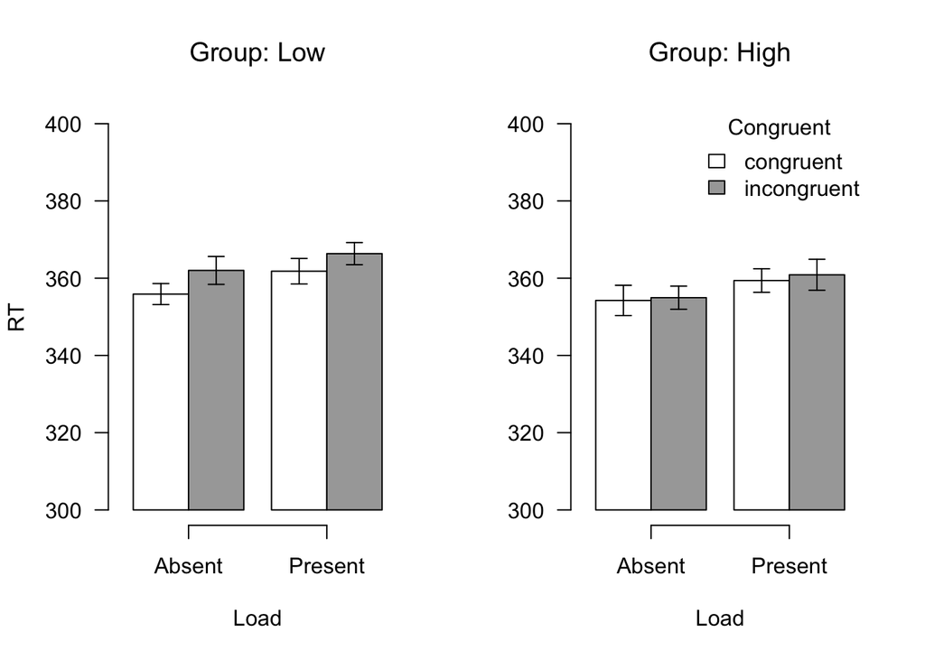

```r
temp <- as.data.frame(gRT1stLev)
temp$SID <- as.factor(temp$SID)
apa_barplot(data=temp,
            id="SID", dv="RT", factors=c("Load","Congruent","Group"),
            dispersion = wsci,
            ylim = c(300, 400),
            las=1)
```

개인차가 너무 커서 조건간 차이가 잘 보이지 않는다. *Congruency* 효과를 계산하여 다시 그렸다.

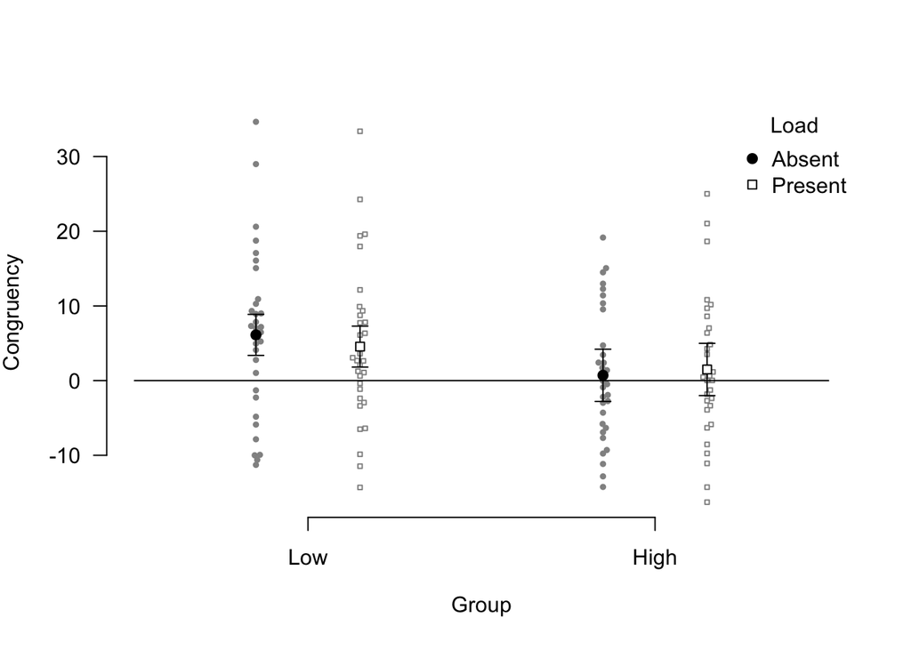

```r
temp <- as.data.frame(gRT1stLev2)
temp$SID <- as.factor(temp$SID)
apa_beeplot(data=temp,
            id="SID", dv="Congruency", factors=c("Group","Load"),
            dispersion = wsci,
            intercept = 0,
            # args_swarm = list(col="darkgray"),
            # args_points = list(col="red"),
            # args_error_bars = list(col="red"),
            args_legend = list(x="topright"),
            las=1)
```

#### 다. ANOVA & Post-hoc

`afex` 패키지의 aov_ez의 코드가 가장 해석하기 편하다.[^4]

```r
m1 <- aov_ez("SID", "RT", sTT,
                between = "Group",
                within = c("Load","Congruent"))
```

```
## Contrasts set to contr.sum for the following variables: Group
```

```r
# m1 <- aov_4(RT ~ Load*Congruent*Group + (Load*Congruent|SID), sTT) # 결과는 같음.
# m1 <- aov_car(RT ~ Load*Congruent*Group + Error(SID/(Load*Congruent)), sTT) # 결과는 같음.

knitr::kable(nice(m1))
```

| Effect | df | MSE | F | ges | p.value |
| --- | --- | --- | --- | --- | --- |
| Group | 1, 62 | 3961.61 | 0.28 | .004 | .60 |
| Load | 1, 62 | 158.43 | 11.51 ** | .007 | .001 |
| Group:Load | 1, 62 | 158.43 | 0.02 | <.0001 | .90 |
| Congruent | 1, 62 | 61.13 | 10.85 ** | .003 | .002 |
| Group:Congruent | 1, 62 | 61.13 | 4.70 * | .001 | .03 |
| Load:Congruent | 1, 62 | 38.00 | 0.07 | <.0001 | .80 |
| Group:Load:Congruent | 1, 62 | 38.00 | 0.58 | <.0001 | .45 |

*Group:Congruent* 이원 상호작용이 있었고 *Group:Load:Congruent* 삼원 상호작용은 유의하지 않았다.

이제 `emmeans` 패키지를 사용하여 *Group:Load* 조건별 *Congruent* 효과를 비교하였다.

```r
em_m1 <- emmeans(m1, ~Congruent:Load:Group)
my.posthoc <- list(
  lo.abs  = c(-1, 1, 0, 0, 0, 0, 0, 0),
  lo.pre  = c(0, 0, -1, 1, 0, 0, 0, 0),
  hi.abs  = c(0, 0, 0, 0, -1, 1, 0, 0),
  hi.pre  = c(0, 0, 0, 0, 0, 0, -1, 1)
)
contrast(em_m1, my.posthoc, adjust = "mvt") # ?summary.emmGrid
```

```
##  contrast  estimate       SE    df t.ratio p.value
##  lo.abs   6.1209613 1.760094 117.6   3.478  0.0028
##  lo.pre   4.5524738 1.760094 117.6   2.586  0.0424
##  hi.abs   0.7113087 1.760094 117.6   0.404  0.9897
##  hi.pre   1.4900734 1.760094 117.6   0.847  0.8629
##
## P value adjustment: mvt method for 4 tests
```

```r
# contrast(em_m1, mycontrast, adjust = "none")
# contrast(em_m1, mycontrast, adjust = "bonferroni")
# contrast(em_m1, mycontrast, adjust = "tukey") # -> sidak으로 바뀜: 참가자내 -> 참가자간 변인 취급하는 듯
```

작업기억 부하 유무에 상관없이 일치효과가 low load 집단에서는 나타났고, high load 집단에서는 보이지 않았다. 위 분석은 다중비교 보정을 위해 `mvt` method를 사용하였다. Lenth의 설명은 아래와 같다.[^5]

> An adjustment method that is usually appropriate is Bonferroni; however, it can be quite conservative. Using adjust = “mvt” is the closest to being the “exact” all-around method “single-step” method, as it uses the multivariate t distribution (and the mvtnorm package) with the same covariance structure as the estimates to determine the adjustment. However, this comes at high computational expense as the computations are done using simulation techniques. For a large set of tests (and especially confidence intervals), the computational lag becomes noticeable if not intolerable.

`emmeans` 패키지에서는 추정치를 그림으로 그려주는 함수를 제공한다.

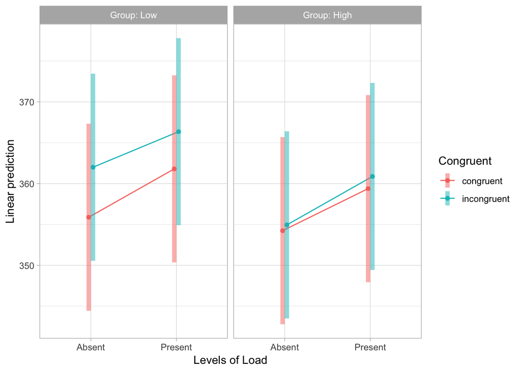

```r
emmip(m1, Congruent ~ Load|Group, CIs = TRUE) +
  ggplot2::theme_light()
```

### 2. Go/Nogo 과제 정확율

#### 가. 기술통계

먼저 참가자 자신의 표적이 출현한 시행들만 분석하여 그림을 그렸다.

```r
mTT <- TT %>%
  filter(Congruent!="notme") %>% # 표적시행만 선별
  droplevels %>%  # "notme" level 제거
  select(Group, Load, Congruent, SID, Epoch, Trial, Correct)
headTail(mTT)
```

```
##       Group    Load   Congruent SID Epoch Trial Correct
## 1       Low  Absent   congruent 101     1     1       1
## 2       Low  Absent incongruent 101     1     5       1
## 3       Low  Absent   congruent 101     1     6       1
## 4       Low  Absent incongruent 101     1     7       1
## ...    <NA>    <NA>        <NA> ...   ...   ...     ...
## 15357  High Present   congruent 232     4   474       1
## 15358  High Present incongruent 232     4   475       1
## 15359  High Present   congruent 232     4   476       1
## 15360  High Present   congruent 232     4   479       1
```

```r
gAcc1stLev2 <- TT %>%
  filter(Congruent!="notme") %>%
  droplevels %>%
  group_by(Group, Load, Congruent, SID) %>%
  summarise(Accuracy = mean(Correct)) %>%
  ungroup()
gAcc1stLev2
```

```
## # A tibble: 256 x 5
##    Group Load   Congruent   SID Accuracy
##    <fct> <fct>  <fct>     <int>    <dbl>
##  1 Low   Absent congruent   101    0.967
##  2 Low   Absent congruent   102    1
##  3 Low   Absent congruent   103    1
##  4 Low   Absent congruent   104    0.967
##  5 Low   Absent congruent   105    1
##  6 Low   Absent congruent   106    0.917
##  7 Low   Absent congruent   107    1
##  8 Low   Absent congruent   108    0.967
##  9 Low   Absent congruent   109    1
## 10 Low   Absent congruent   110    0.9
## # ... with 246 more rows
```

```r
unique(gAcc1stLev2$Congruent)
```

```
## [1] congruent   incongruent
## Levels: congruent incongruent
```

```r
gAcc2ndLev2 <- gAcc1stLev2 %>%
  group_by(Group, Load, Congruent) %>%
  summarise(Acc = mean(Accuracy),
            CI = ci(Accuracy)) %>%
  ungroup()
colnames(gAcc2ndLev2)[4] <- "Accuracy"
gAcc2ndLev2
```

```
## # A tibble: 8 x 5
##   Group Load    Congruent   Accuracy     CI
##   <fct> <fct>   <fct>          <dbl>  <dbl>
## 1 Low   Absent  congruent      0.971 0.0177
## 2 Low   Absent  incongruent    0.968 0.0176
## 3 Low   Present congruent      0.976 0.0137
## 4 Low   Present incongruent    0.967 0.0172
## 5 High  Absent  congruent      0.982 0.0133
## 6 High  Absent  incongruent    0.971 0.0144
## 7 High  Present congruent      0.971 0.0216
## 8 High  Present incongruent    0.974 0.0188
```

#### 나. Plotting

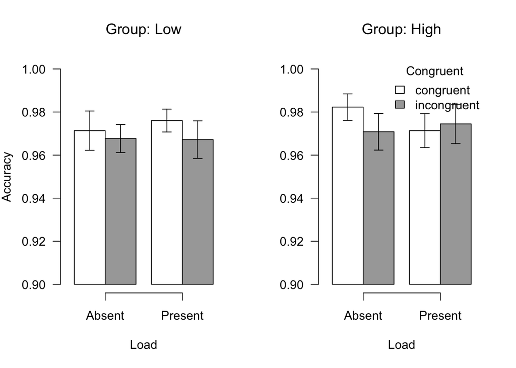

```r
temp <- as.data.frame(gAcc1stLev2)
temp$SID <- as.factor(temp$SID)
apa_barplot(data=temp,
            id="SID", dv="Accuracy", factors=c("Load","Congruent","Group"),
            dispersion = wsci,
            ylim = c(0.9, 1),
            args_legend = list(x="topright"),
            las=1)
```

Go/Nogo 과제의 정확율이 매우 높은 편이지만 조건간 차이가 보인다. 특히, high load 집단에서 작업기억 부하가 없을 때 일치효과가 두드러진다.

#### 다. ANOVA & Post-hoc

```r
m2 <- aov_ez("SID", "Correct", mTT,
             between = "Group",
             within = c("Load","Congruent"))
```

```
## Contrasts set to contr.sum for the following variables: Group
```

```r
knitr::kable(nice(m2))
```

| Effect | df | MSE | F | ges | p.value |
| --- | --- | --- | --- | --- | --- |
| Group | 1, 62 | 0.01 | 0.15 | .002 | .70 |
| Load | 1, 62 | 0.00 | 0.06 | <.0001 | .80 |
| Group:Load | 1, 62 | 0.00 | 0.83 | .0010 | .37 |
| Congruent | 1, 62 | 0.00 | 4.59 * | .003 | .04 |
| Group:Congruent | 1, 62 | 0.00 | 0.18 | .0001 | .67 |
| Load:Congruent | 1, 62 | 0.00 | 0.90 | .0006 | .35 |
| Group:Load:Congruent | 1, 62 | 0.00 | 4.02 * | .003 | .05 |

*Group:Load:Congruent*의 삼원상호작용이 나타났다. 집단별 작업기억 부하의 효과가 달랐기 때문이다.

```r
em_m2 <- emmeans(m2, ~Congruent:Load:Group)
my.posthoc <- list(
  lo.abs  = c(-1, 1, 0, 0, 0, 0, 0, 0),
  lo.pre  = c(0, 0, -1, 1, 0, 0, 0, 0),
  hi.abs  = c(0, 0, 0, 0, -1, 1, 0, 0),
  hi.pre  = c(0, 0, 0, 0, 0, 0, -1, 1)
)
contrast(em_m2, my.posthoc, adjust = "mvt") # ?summary.emmGrid
```

```
##  contrast     estimate          SE     df t.ratio p.value
##  lo.abs   -0.003645833 0.004901496 123.97  -0.744  0.9125
##  lo.pre   -0.008854167 0.004901496 123.97  -1.806  0.2607
##  hi.abs   -0.011458333 0.004901496 123.97  -2.338  0.0810
##  hi.pre    0.003125000 0.004901496 123.97   0.638  0.9481
##
## P value adjustment: mvt method for 4 tests
```

반응시간 결과와 달리, High load 집단은 작업기억을 사용하지 않을 때 일치효과를 보이고 있다. 다중비교 보정을 하지 않으면 결과가 다음과 같다.

```r
em_m2 <- emmeans(m2, ~Congruent:Load:Group)
my.posthoc <- list(
  lo.abs  = c(-1, 1, 0, 0, 0, 0, 0, 0),
  lo.pre  = c(0, 0, -1, 1, 0, 0, 0, 0),
  hi.abs  = c(0, 0, 0, 0, -1, 1, 0, 0),
  hi.pre  = c(0, 0, 0, 0, 0, 0, -1, 1)
)
contrast(em_m2, my.posthoc, adjust = "none") # ?summary.emmGrid
```

```
##  contrast     estimate          SE     df t.ratio p.value
##  lo.abs   -0.003645833 0.004901496 123.97  -0.744  0.4584
##  lo.pre   -0.008854167 0.004901496 123.97  -1.806  0.0733
##  hi.abs   -0.011458333 0.004901496 123.97  -2.338  0.0210
##  hi.pre    0.003125000 0.004901496 123.97   0.638  0.5249
```

#### 라. 비표적 시행 반응

자신의 표적이 아닐 때 실수로 반응했을 가능성을 비교하였다.

```r
gAcc1stLev2 <- TT %>%
  filter(Congruent=="notme") %>%
  droplevels %>%
  group_by(Group, Load, SID) %>%
  summarise(Accuracy = mean(Correct)) %>%
  select(Group, Load, SID, Accuracy)
gAcc1stLev2
```

```
## # A tibble: 128 x 4
## # Groups:   Group, Load [4]
##    Group Load     SID Accuracy
##    <fct> <fct>  <int>    <dbl>
##  1 Low   Absent   101    0.992
##  2 Low   Absent   102    1
##  3 Low   Absent   103    1
##  4 Low   Absent   104    1
##  5 Low   Absent   105    0.983
##  6 Low   Absent   106    0.992
##  7 Low   Absent   107    1
##  8 Low   Absent   108    1
##  9 Low   Absent   109    1
## 10 Low   Absent   110    0.983
## # ... with 118 more rows
```

```r
gAcc2ndLev2 <- gAcc1stLev2 %>%
  group_by(Group, Load) %>%
  summarise(Acc = mean(Accuracy),
            CI = ci(Accuracy)) %>%
  ungroup()
colnames(gAcc2ndLev2)[2] <- "Accuracy"
gAcc2ndLev2
```

```
## # A tibble: 4 x 4
##   Group Accuracy   Acc      CI
##   <fct> <fct>    <dbl>   <dbl>
## 1 Low   Absent   0.996 0.00241
## 2 Low   Present  0.995 0.00215
## 3 High  Absent   0.990 0.00470
## 4 High  Present  0.991 0.00463
```

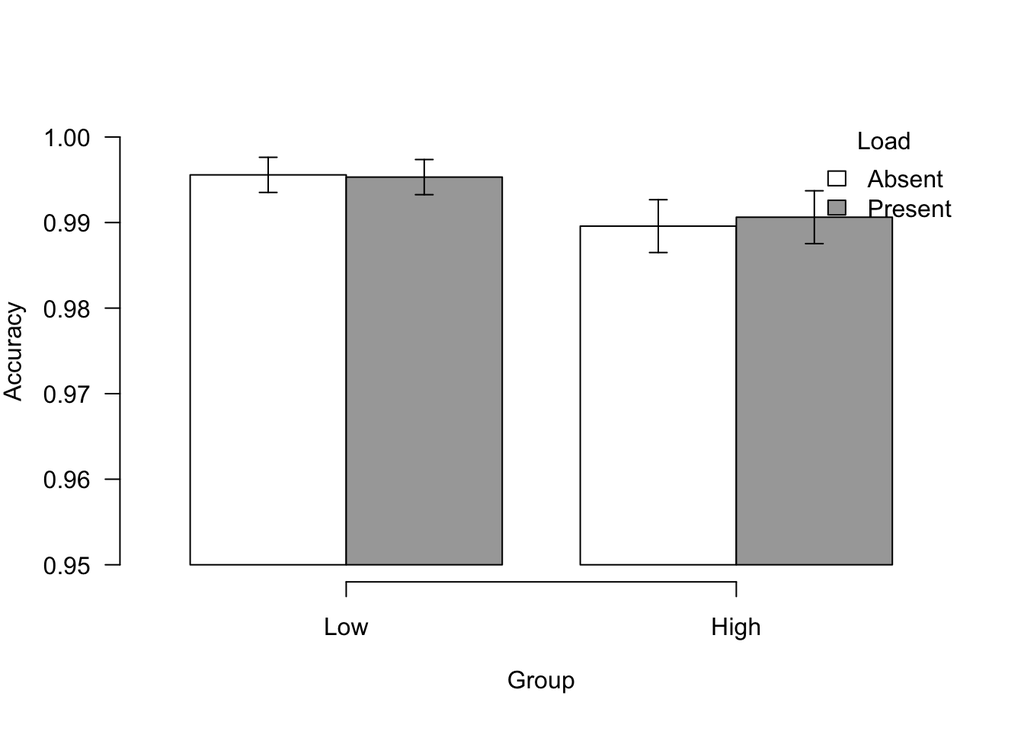

```r
temp <- as.data.frame(gAcc1stLev2)
temp$SID <- as.factor(temp$SID)
apa_barplot(data=temp,
            id="SID", dv="Accuracy", factors=c("Group","Load"),
            dispersion = wsci,
            ylim = c(0.95, 1),
            args_legend = list(x="topright"),
            las=1)
```

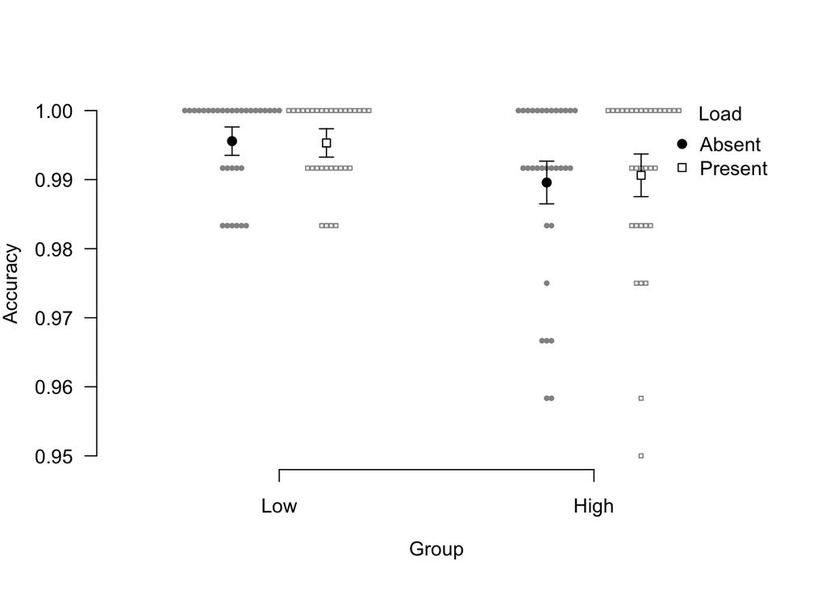

```r
temp <- as.data.frame(gAcc1stLev2)
temp$SID <- as.factor(temp$SID)
apa_beeplot(data=temp,
            id="SID", dv="Accuracy", factors=c("Group","Load"),
            dispersion = wsci,
            intercept = 0,
            ylim = c(0.95, 1),
            args_legend = list(x="topright"),
            las=1)
```

```r
m3 <- aov_ez("SID", "Accuracy", gAcc1stLev2,
             between = "Group",
             within = "Load")
```

```
## Contrasts set to contr.sum for the following variables: Group
```

```r
knitr::kable(nice(m3))
```

| Effect | df | MSE | F | ges | p.value |
| --- | --- | --- | --- | --- | --- |
| Group | 1, 62 | 0.00 | 5.90 * | .07 | .02 |
| Load | 1, 62 | 0.00 | 0.09 | .0004 | .76 |
| Group:Load | 1, 62 | 0.00 | 0.26 | .001 | .61 |